# RRBS - Array Comparison for rTg4510 Interaction term

Emma Walker

## Introduction

Many of the entorhinal cortex samples were ran on both the methylation array and using RRBS technology so can be compared. NB these MAY NOT BE identical samples however.

This script looks at the overlap between sites on the two technologies for the regression results for the rTg4510 ECX Interaction models.

Note that these results are PRE FILTERING.

There are 928 signifcant results for the regressions on the array data

There are 2203 signifcant results for the regressions on the RRBS data

## Significant locations that have an identical location in the other technology

# Sites that are significant in both technologies

There are 2269 sites which are in both technologies and 0 sites which are significant using both technologies.

# Sites that are significant in the array data

There are 58 sites which are significant for the array data and have corresponding locations for the RRBS data. RRBS significance for these 58 sites has been calculated using both bonferroni correction and also FDR adjusted as that is what was used for previous P value adjustments in both the RRBS and array data. There are 2 sites which are also significant in the RRBS data using the bonferonni correction, and 2 sites which are also significant in the RRBS data using the FDR adjustment.

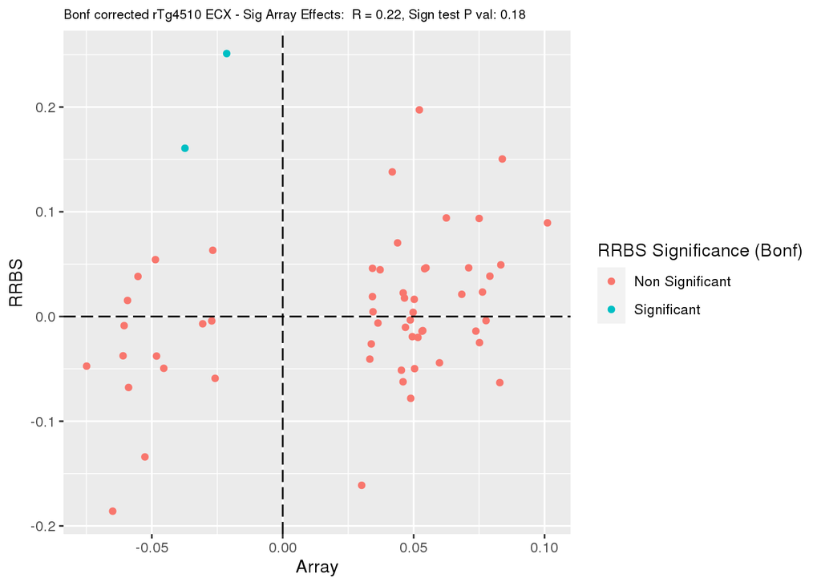

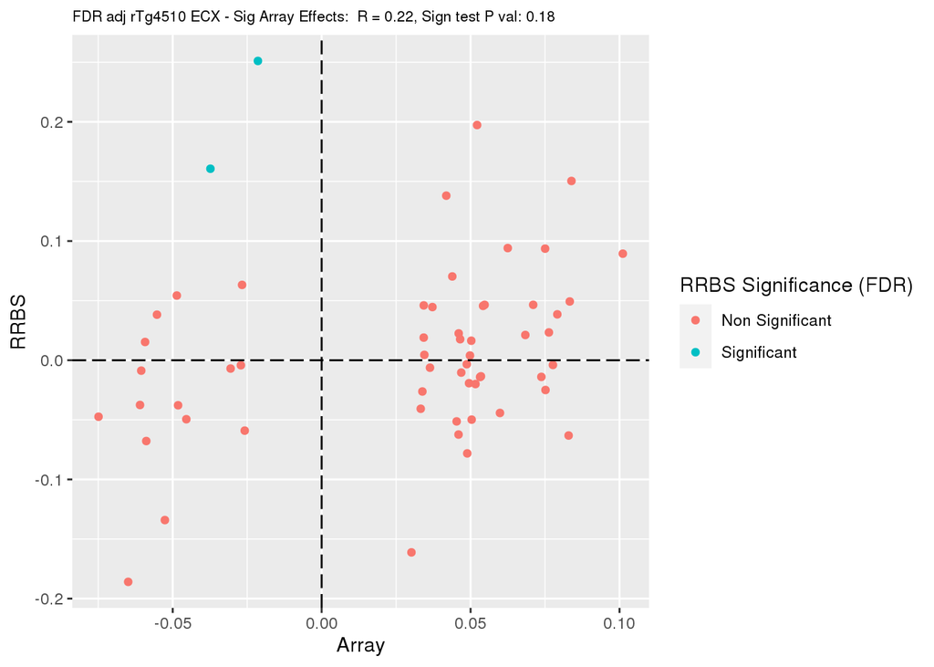

# Sites that are significant in the RRBS data

There are 1 sites which are significant for the RRBS data and have corresponding locations for the array data. The correspondng site in the array data is not nominally significant (0.729). The effect size is negative using both technologies.

## Significant array sites and RRBS sites +/-100bp

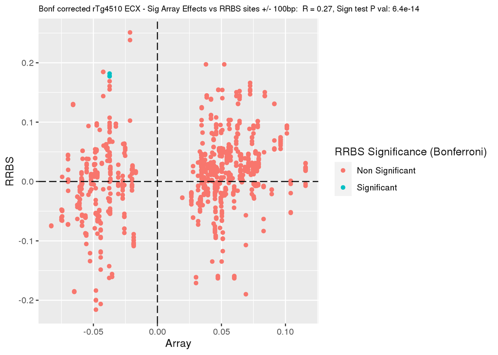

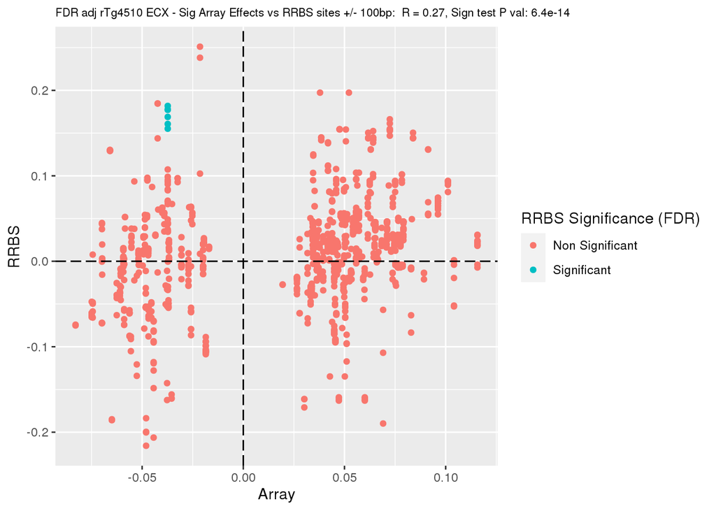

There are 187 significant DMPSs on the array which have a RRBS postion within +/-100bp (909 unique RRBS locations) totalling 1041 site pairs.

## Significant RRBS sites and array sites +/-100bp

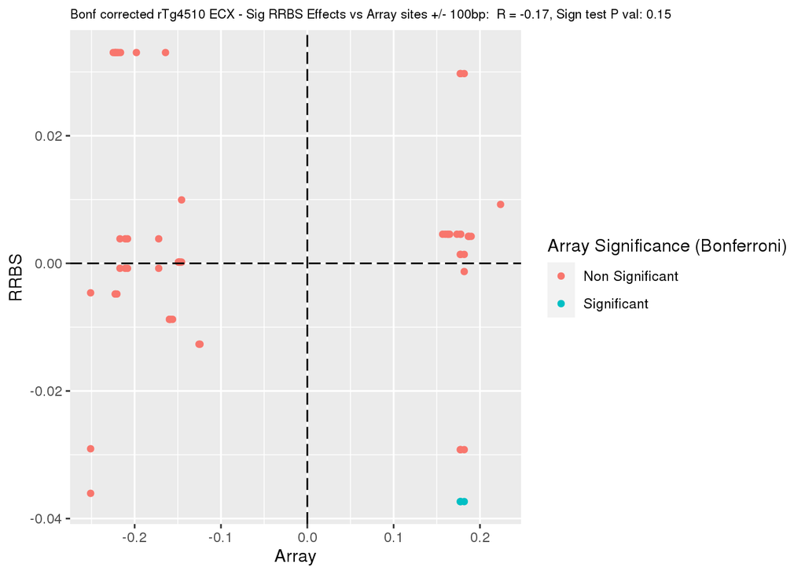

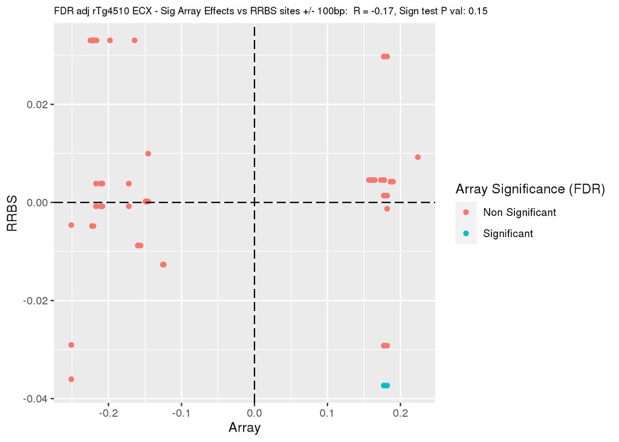

There are 41 significant DMPSs from the RRBS data which have an Array postion within +/-100bp (19 unique array locations) totalling 61 site pairs.

## There are no rTg4510 Interaction DMRs tp use for comparison

## Gene level overlaps between the two technologies

There are 5 unique genes which contain at least one significant site/cpg from both the RRBS and array data.

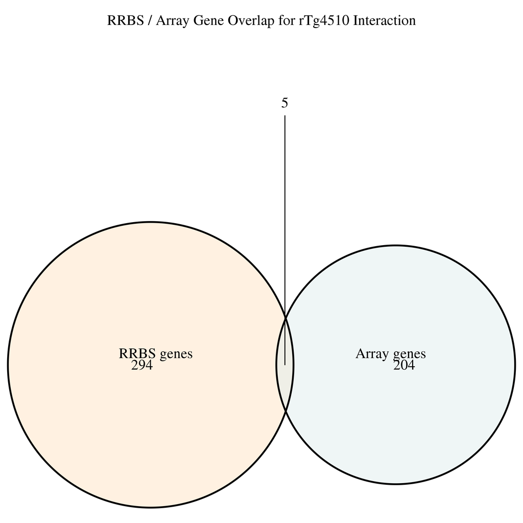